# Homework 2

*Ahmet Sualp Say - IE582 - Fall 2021*

```r
options(scipen=999)
```

### Task 1 – Dimensionality reduction

Consider a classification problem where you have only two features (the data is on Moodle). You decided to visualize the instances on a 2D feature space where the class information is color-coded.

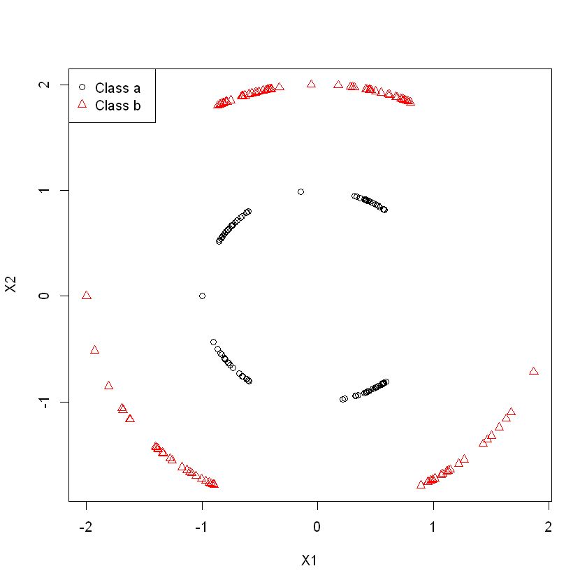

```r
require(data.table)

# assuming you have the homework data in your working directory in the following format:
# 'working_directory/'
current_folder = getwd()

data=read.csv('IE582_Fall21_HW2_q1_data.csv', header=T)
class=as.numeric(data[,3])
plot(data[,1], data[,2], col=class, pch=class, xlab=names(data)[1], ylab=names(data)[2])
legend("topleft", paste("Class", levels(data[,3])), col=unique(class), pch=unique(class))
```

*a) Apply PCA to reduce the number of dimensions to one and visualize the instances on a scatter plot. Note that the scatter plot will show the observation number versus the observed value (as we have a single feature to represent the instance).*

```r
summary(data)
# since the features are in the same scale, there is no need to scale data
```

```
       X1                X2          class
 Min.   :-2.0000   Min.   :-1.7908   a:99
 1st Qu.:-0.7994   1st Qu.:-0.9445   b:99
 Median :-0.2408   Median : 0.2578
 Mean   :-0.1147   Mean   : 0.1006
 3rd Qu.: 0.5128   3rd Qu.: 0.9786
 Max.   : 1.8671   Max.   : 1.9992
```

```r
pca = princomp(data[c(1,2)], cor=T)
summary(pca, loadings=T)
```

```
Importance of components:
                          Comp.1    Comp.2
Standard deviation     1.0004424 0.9995574
Proportion of Variance 0.5004425 0.4995575
Cumulative Proportion  0.5004425 1.0000000

Loadings:
   Comp.1 Comp.2
X1  0.707  0.707
X2  0.707 -0.707
```

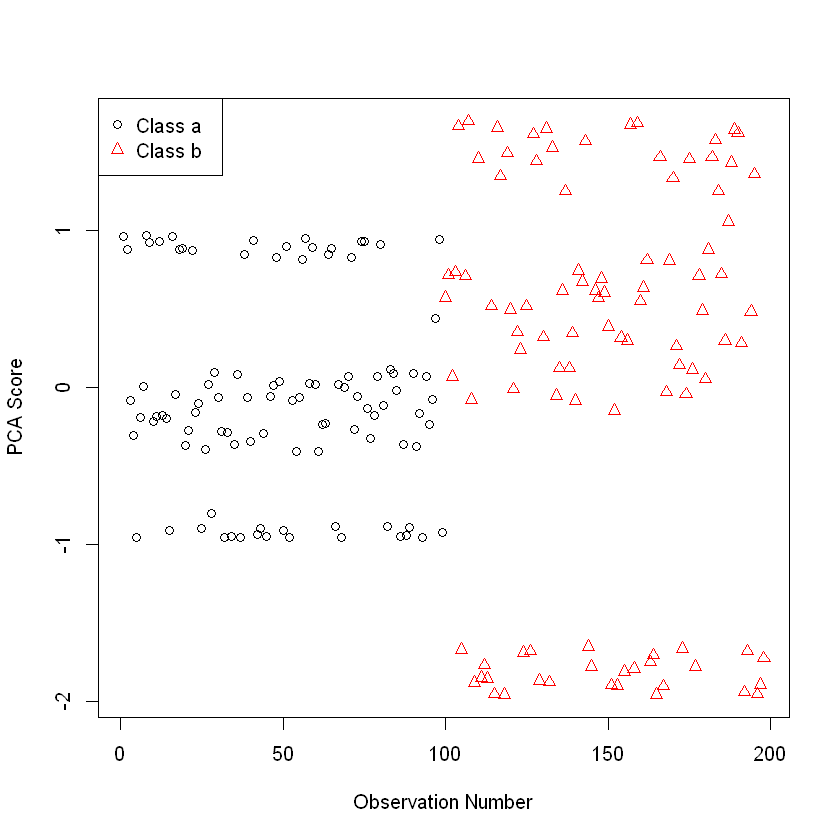

```r
plot(pca$scores[,1], col=data$class, pch=as.numeric(data$class), xlab="Observation Number", ylab="PCA Score")
legend("topleft", paste("Class", levels(data[,3])), col=unique(class), pch=unique(class))
```

*b) Apply MDS to reduce the number of dimensions to one and visualize the instances on a scatter plot as in part (a). Use at least two different similarity measure.*

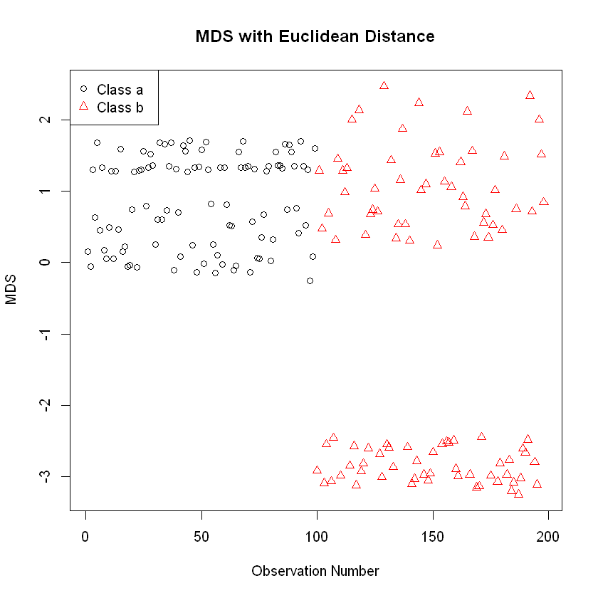

```r
# compute distance matrix
d <- dist(data, method="euclidean")

# perform MDS
mds_1 <- cmdscale(d, k=1)
plot(mds_1, col=data$class, pch=as.numeric(data$class), xlab="Observation Number", ylab="MDS", main="MDS with Euclidean Distance")
legend("topleft", paste("Class", levels(data[,3])), col=unique(class), pch=unique(class))
```

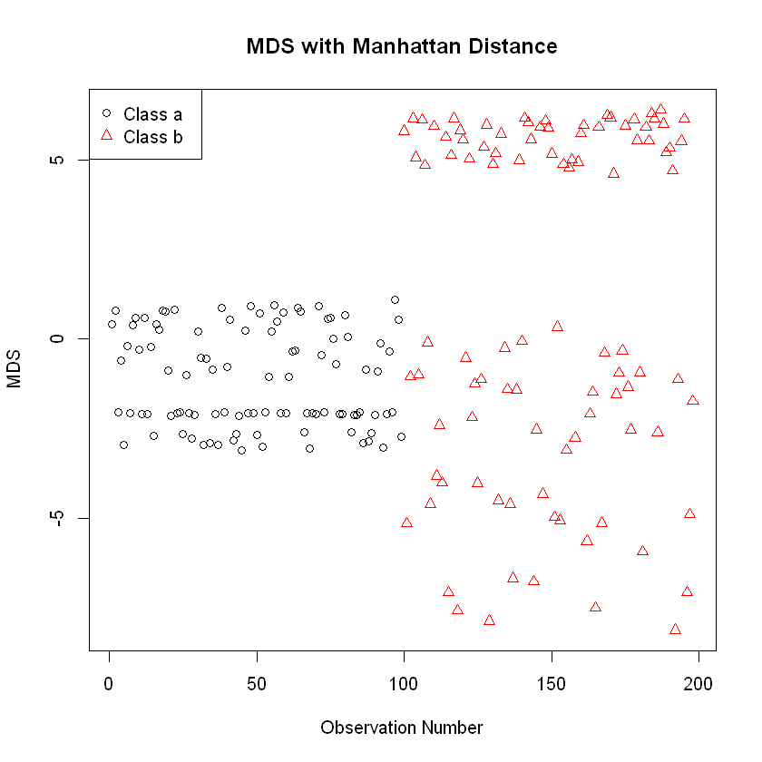

```r
# compute distance matrix
d <- dist(data, method="manhattan")

# perform MDS
mds_1 <- cmdscale(d, k=1)
plot(mds_1, col=data$class, pch=as.numeric(data$class), xlab="Observation Number", ylab="MDS", main="MDS with Manhattan Distance")
legend("topleft", paste("Class", levels(data[,3])), col=unique(class), pch=unique(class))
```

*c) On a 2D scatter plot, one can observe how two observations from two classes are different.*

###### It is not enough seperable, especially the observations in the middle

###### Except for some observations, the data is as seperable as with two features. But one cannot underestimate the effect of used distance method. Manhattan distance seems worked better than the Euicledean.

###### Since it is known that PCA works well when there is linear relation between features. Here, variables follows a nonlinear relation. So, it seems that MDS worked better when seperating the observations

*d) Suppose, you are not satisfied with your dimensionality reduction scheme in part (a). Add the following columns to your data, squared term of X1 and X2 and interaction term (three columns as functions of your original variables) and apply PCA. Comment on the PCA results (i.e. what are the eigenvalues? What do they refer to?).*

```r
data$X12 <- data$X1^2
data$X22 <- data$X2^2
data$X1X2 <- data$X1*data$X2
```

```r
pca = princomp(data[c(1,2,4,5,6)], cor=T)
summary(pca, loadings=T)
```

```
Importance of components:
                          Comp.1    Comp.2    Comp.3    Comp.4     Comp.5
Standard deviation     1.3114557 1.1508988 0.9723549 0.7988684 0.60979578
Proportion of Variance 0.3439832 0.2649136 0.1890948 0.1276382 0.07437018
Cumulative Proportion  0.3439832 0.6088968 0.7979917 0.9256298 1.00000000

Loadings:
     Comp.1 Comp.2 Comp.3 Comp.4 Comp.5
X1    0.419  0.556  0.128  0.571  0.415
X2    0.538 -0.454        -0.368  0.600
X12  -0.539  0.162  0.578 -0.273  0.524
X22   0.351 -0.313  0.797  0.127 -0.356
X1X2 -0.348 -0.600         0.669  0.258
```

###### 0.419*X1 + 0.538*X2 -0.539*X12 + 0.351*X22 -0.348*X1X2 is the equation to be used by the one who will reduce the dimension of data from 5 to 1.

### Task 2 – Reconstructing Turkey Map

Please download the intercity distance information from Karayolları Genel Müdürlüğü’s website from the link below: https://www.kgm.gov.tr/SiteCollectionDocuments/KGMdocuments/Root/Uzakliklar/ilmesafe.xls

*Suppose we apply MDS to this data to distance matrix to obtain latent variables in 2D dimensional space. Represent the new feature space on a 2D plot. You are expected to label each data point with the respective city’s name. This plot should be similar to Turkey map. Are there any unusual observations? If yes, comment on your findings.*

```r
require(readxl)
```

```r
distance_matrix = as.matrix(read_excel("ilmesafe.xls", skip=2))
distance_matrix = distance_matrix[,-1]
row.names(distance_matrix) = distance_matrix[, 1]
distance_matrix = distance_matrix[, -1]
distance_matrix =`class<-`(distance_matrix, 'numeric')
head(distance_matrix)
```

|  | ADANA | ADIYAMAN | AFYONKARAHİSAR | AĞRI | AMASYA | ANKARA | ANTALYA | ARTVİN | AYDIN | BALIKESİR | ... | BATMAN | ŞIRNAK | BARTIN | ARDAHAN | IĞDIR | YALOVA | KARABÜK | KİLİS | OSMANİYE | DÜZCE |
| --- | --- | --- | --- | --- | --- | --- | --- | --- | --- | --- | --- | --- | --- | --- | --- | --- | --- | --- | --- | --- | --- |
| ADANA | NA | 335 | 575 | 966 | 603 | 567 | 535 | 1035 | 874 | 903 | ... | 621 | 709 | 782 | 1042 | 1066 | 899 | 714 | 246 | 87 | 735 |
| ADIYAMAN | 335 | NA | 910 | 648 | 632 | 814 | 870 | 751 | 1209 | 1238 | ... | 303 | 471 | 1023 | 758 | 748 | 1147 | 955 | 210 | 248 | 976 |
| AFYONKARAHİSAR | 575 | 910 | NA | 1318 | 597 | 300 | 290 | 1243 | 345 | 328 | ... | 1196 | 1284 | 515 | 1351 | 1461 | 338 | 447 | 821 | 662 | 375 |
| AĞRI | 966 | 648 | 1318 | NA | 738 | 1141 | 1428 | 396 | 1640 | 1569 | ... | 369 | 430 | 1175 | 310 | 143 | 1363 | 1106 | 814 | 879 | 1192 |
| AMASYA | 603 | 632 | 597 | 736 | NA | 413 | 825 | 695 | 938 | 831 | ... | 796 | 982 | 437 | 783 | 881 | 625 | 368 | 639 | 608 | 454 |
| ANKARA | 492 | 742 | 256 | 1054 | 333 | NA | 542 | 979 | 597 | 536 | ... | 1001 | 1147 | 283 | 1087 | 1197 | 407 | 215 | 710 | 579 | 236 |

```r
# make symetric
distance_matrix[lower.tri(distance_matrix)] = t(distance_matrix)[lower.tri(distance_matrix)]
head(distance_matrix)
```

|  | ADANA | ADIYAMAN | AFYONKARAHİSAR | AĞRI | AMASYA | ANKARA | ANTALYA | ARTVİN | AYDIN | BALIKESİR | ... | BATMAN | ŞIRNAK | BARTIN | ARDAHAN | IĞDIR | YALOVA | KARABÜK | KİLİS | OSMANİYE | DÜZCE |
| --- | --- | --- | --- | --- | --- | --- | --- | --- | --- | --- | --- | --- | --- | --- | --- | --- | --- | --- | --- | --- | --- |
| ADANA | NA | 335 | 575 | 966 | 603 | 567 | 535 | 1035 | 874 | 903 | ... | 621 | 709 | 782 | 1042 | 1066 | 899 | 714 | 246 | 87 | 735 |
| ADIYAMAN | 335 | NA | 910 | 648 | 632 | 814 | 870 | 751 | 1209 | 1238 | ... | 303 | 471 | 1023 | 758 | 748 | 1147 | 955 | 210 | 248 | 976 |
| AFYONKARAHİSAR | 575 | 910 | NA | 1318 | 597 | 300 | 290 | 1243 | 345 | 328 | ... | 1196 | 1284 | 515 | 1351 | 1461 | 338 | 447 | 821 | 662 | 375 |
| AĞRI | 966 | 648 | 1318 | NA | 738 | 1141 | 1428 | 396 | 1640 | 1569 | ... | 369 | 430 | 1175 | 310 | 143 | 1363 | 1106 | 814 | 879 | 1192 |
| AMASYA | 603 | 632 | 597 | 738 | NA | 413 | 825 | 695 | 938 | 831 | ... | 796 | 982 | 437 | 783 | 881 | 625 | 368 | 639 | 608 | 454 |
| ANKARA | 567 | 814 | 300 | 1141 | 413 | NA | 542 | 979 | 597 | 536 | ... | 1001 | 1147 | 283 | 1087 | 1197 | 407 | 215 | 710 | 579 | 236 |

```r
# perform MDS
distance_matrix[is.na(distance_matrix)] = 0
d <- cmdscale(distance_matrix, eig = TRUE, k = 2)
```

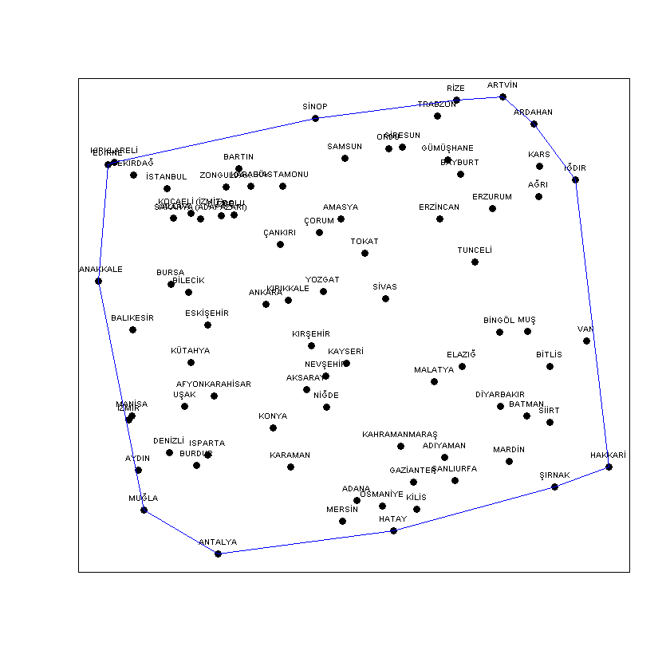

```r
Plot_ConvexHull<-function(xcoord, ycoord, lcolor){
hpts = chull(x = xcoord, y = ycoord)
hpts = c(hpts, hpts[1])
lines(xcoord[hpts], ycoord[hpts], col = lcolor)
}

xrange = range(c(d$points[, 1]))
yrange = range(c(d$points[, 2]))

par(tck = 0.02, mgp = c(1.7, 0.3, 0))

# draw locations
plot(d$points[, 1], d$points[, 2], type = "p", pch = 19, col = "black", xaxt = "n", yaxt = "n", xlab = "", ylab = "", xlim = c(xrange), ylim = c(yrange))
city.names = colnames(distance_matrix)
text(x=d$points[, 1], y=d$points[, 2], pos = 3, labels = city.names, cex=0.5)

# draw borders
Plot_ConvexHull(xcoord = d$points[, 1], ycoord = d$points[, 2], lcolor = "blue")
```

###### We lose information for sure while reconstructing the map. But still, one can see that Antalya is the southernmost city along with Hakkari lays in the most southeast and also nearly all the remaining cities are located in their correct location.

### Task 3 – Dimensionality reduction for time series data

Note that there are separate files for each axis and each row corresponds to one gesture in the files. First column has the class information. The information between second and last column is the time ordered observations in the corresponding axis (provided in the file name as X, Y or Z). Moreover, the data is split into training and test sets. For now, you are expected to work with only the training series. Hence, following files are to be used:

• uWaveGestureLibrary_X_TRAIN,

• uWaveGestureLibrary_Y_TRAIN,

• uWaveGestureLibrary_Z_TRAINm

```r
require(data.table)

# assuming you have the XYZ cordinates in your working directory in the following format:
# 'working_directory/'
current_folder = getwd()

file_names = list.files(pattern = "uWaveGestureLibrary")
list_files = lapply(file_names, read.table)

list_files = lapply(seq_along(list_files), function(x) {
  list_files[[x]]$V0 = 1:nrow(list_files[[x]]) # column VO is created to specify the sample instance
  list_files[[x]]
})
```

```r
x = as.data.table(list_files[1])
y = as.data.table(list_files[2])
z = as.data.table(list_files[3])


# melt X cordinates for long format
setnames(x,"V1","class")
setnames(x,"V0","instance")
x = melt(x,id.vars=c('class','instance'))
x[,time:=as.numeric(gsub("\\D", "", variable))-1]
x = x[,list(class,instance, time, value)]
x = x[order(instance, class,time)]
setnames(x, "value", "x_cordinate")


# melt Y cordinates for long format
setnames(y,"V1","class")
setnames(y,"V0","instance")
y = melt(y,id.vars=c('class','instance'))
y[,time:=as.numeric(gsub("\\D", "", variable))-1]
y = y[,list(class,instance, time, value)]
y = y[order(instance, class, time)]
setnames(y, "value", "y_cordinate")

# melt Z cordinates  for long format
setnames(z,"V1","class")
setnames(z,"V0","instance")
z = melt(z,id.vars=c('class','instance'))
z[,time:=as.numeric(gsub("\\D", "", variable))-1]
z = z[,list(class, instance, time, value)]
z = z[order(instance, class, time)]
setnames(z, "value", "z_cordinate")


xy = merge(x,
            y,
            by=c("class","instance","time"))


xyz = merge(xy,
            z,
            by=c("class","instance","time"))
```

```r
# shows x,y,z cordinates of one instance belongs to class 1
head(xyz)
```

| class | instance | time | x_cordinate | y_cordinate | z_cordinate |
| --- | --- | --- | --- | --- | --- |
| 1 | 11 | 1 | -0.7914472 | -1.959984 | -0.2490781 |
| 1 | 11 | 2 | -0.7914472 | -1.959984 | -0.2490781 |
| 1 | 11 | 3 | -0.7958727 | -1.956600 | -0.2514390 |
| 1 | 11 | 4 | -0.8100650 | -1.945750 | -0.2590101 |
| 1 | 11 | 5 | -0.8492300 | -1.915809 | -0.2799033 |
| 1 | 11 | 6 | -0.9034648 | -1.874347 | -0.3088358 |

```r
require(lattice)
```

```r
# instances belong to class 1, 2, 3, 4, 5, 6, 7, 8 respectively
samples <- xyz[instance %in% c(11, 15, 4, 5, 2, 1, 7, 6),]
```

```r
velocity_samples = samples[, list(x_cordinate=cumsum(x_cordinate),
                                  y_cordinate=cumsum(y_cordinate),
                                  z_cordinate=cumsum(z_cordinate)), list(class, instance)]
```

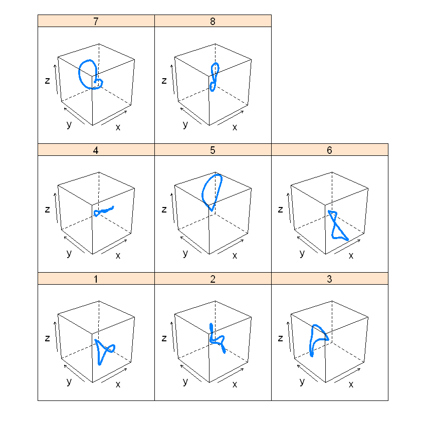

```r
cloud(z_cordinate~x_cordinate*y_cordinate|as.factor(class), data=velocity_samples, xlab="x", ylab="y", zlab="z")
```

*As you may have noticed, the data is provided as a regular data matrix (i.e. each row represents an instance and columns represent the time index of the observations). Assume that X, Y and Z variables are concatenated to obtain a single time series in an unusual way*

*In other words, the information from X, Y and Z axis are concatenated to obtain a single series of length 3T.*

*Apply PCA to the time series from each class in the training data. You are expected to filter the data from each class and apply PCA to the representation.*

```r
x = as.data.table(list_files[1])
x = x[,-317]
colnames(x) = paste0("X", as.numeric(gsub("V", "", colnames(x)))-1)
setnames(x, "X0", "class")

y = as.data.table(list_files[2])
y = y[,-317]
colnames(y) = paste0("Y", as.numeric(gsub("V", "", colnames(y)))-1)
y = y[,-1]

z = as.data.table(list_files[3])
z = z[,-317]
colnames(z) = paste0("Z", as.numeric(gsub("V", "", colnames(z)))-1)
z = z[,-1]

xyz = cbind(x, y, z)
```

```r
head(xyz)
```

| class | X1 | X2 | X3 | X4 | X5 | X6 | X7 | X8 | X9 | ... | Z306 | Z307 | Z308 | Z309 | Z310 | Z311 | Z312 | Z313 | Z314 | Z315 |
| --- | --- | --- | --- | --- | --- | --- | --- | --- | --- | --- | --- | --- | --- | --- | --- | --- | --- | --- | --- | --- |
| 6 | -0.304243210 | -0.304243210 | -0.304243210 | -0.304243210 | -0.304243210 | -0.304243210 | -0.304243210 | -0.304243210 | -0.304243210 | ... | 0.5232168 | 0.5139944 | 0.50348075 | 0.49296714 | 0.47452222 | 0.4560773 | 0.4376324 | 0.4191875 | 0.4007426 | 0.3822976 |
| 5 | 1.627311100 | 1.627311100 | 1.627311100 | 1.627311100 | 1.627311100 | 1.627311100 | 1.627311100 | 1.627311100 | 1.627311100 | ... | -0.4270104 | -0.4270104 | -0.42701043 | -0.42717222 | -0.42877307 | -0.4407199 | -0.4526667 | -0.4646135 | -0.4765603 | -0.4885071 |
| 5 | 0.661276530 | 0.661276530 | 0.661276530 | 0.661276530 | 0.661276530 | 0.661276530 | 0.661276530 | 0.661276530 | 0.661276530 | ... | -0.8627172 | -0.8627172 | -0.86271720 | -0.86271720 | -0.86271720 | -0.8627172 | -0.8627172 | -0.8627172 | -0.8627172 | -0.8627172 |
| 3 | 0.005184784 | 0.005184784 | 0.005184784 | 0.005184784 | 0.005184784 | 0.005184784 | 0.005184784 | 0.005184784 | 0.005184784 | ... | -0.1873845 | -0.1235489 | -0.05587047 | 0.01180812 | 0.07948656 | 0.1570561 | 0.2537396 | 0.4455027 | 0.6485381 | 0.8515735 |
| 4 | 1.286197800 | 1.286197800 | 1.286197800 | 1.286197800 | 1.286197800 | 1.286197800 | 1.286197800 | 1.286197800 | 1.286197800 | ... | 1.8674725 | 1.8343190 | 1.75599960 | 1.63858220 | 1.52116390 | 1.4532661 | 1.5152189 | 1.6326367 | 1.7500543 | 1.8674725 |
| 8 | -0.479252460 | -0.479252460 | -0.479252460 | -0.479252460 | -0.479252460 | -0.479252460 | -0.479252460 | -0.479252460 | -0.479252460 | ... | 0.6979770 | 0.6654623 | 0.63294758 | 0.60043289 | 0.55859021 | 0.5167475 | 0.4679755 | 0.4192035 | 0.3704314 | 0.3216594 |

### Class:1

```r
pca1 = prcomp(xyz[class==1,-c(1, 946)])
summary(pca1)
```

```
Importance of components:
                          PC1    PC2     PC3     PC4     PC5     PC6     PC7
Standard deviation     9.9395 8.4482 6.59507 6.44782 5.59197 5.43668 5.04443
Proportion of Variance 0.2069 0.1494 0.09108 0.08705 0.06548 0.06189 0.05328
Cumulative Proportion  0.2069 0.3563 0.44739 0.53444 0.59992 0.66181 0.71510
                           PC8     PC9    PC10    PC11    PC12    PC13    PC14
Standard deviation     4.05127 3.84269 3.22526 3.11405 2.86242 2.73875 2.67252
Proportion of Variance 0.03437 0.03092 0.02178 0.02031 0.01716 0.01571 0.01496
Cumulative Proportion  0.74946 0.78038 0.80216 0.82247 0.83963 0.85533 0.87029
                          PC15    PC16    PC17    PC18    PC19    PC20   PC21
Standard deviation     2.52453 2.34745 2.20371 2.12927 2.09806 1.96238 1.8016
Proportion of Variance 0.01335 0.01154 0.01017 0.00949 0.00922 0.00806 0.0068
Cumulative Proportion  0.88363 0.89517 0.90534 0.91483 0.92405 0.93211 0.9389
                          PC22    PC23    PC24    PC25    PC26    PC27    PC28
Standard deviation     1.71820 1.63228 1.50764 1.39401 1.32456 1.26692 1.15851
Proportion of Variance 0.00618 0.00558 0.00476 0.00407 0.00367 0.00336 0.00281
Cumulative Proportion  0.94509 0.95067 0.95543 0.95950 0.96317 0.96653 0.96934
                          PC29   PC30    PC31    PC32    PC33    PC34    PC35
Standard deviation     1.12680 1.0917 1.03159 0.98797 0.93504 0.83343 0.82177
Proportion of Variance 0.00266 0.0025 0.00223 0.00204 0.00183 0.00145 0.00141
Cumulative Proportion  0.97200 0.9745 0.97673 0.97877 0.98060 0.98206 0.98347
                          PC36    PC37    PC38    PC39   PC40   PC41   PC42
Standard deviation     0.78185 0.75130 0.70250 0.66657 0.6573 0.6187 0.5772
Proportion of Variance 0.00128 0.00118 0.00103 0.00093 0.0009 0.0008 0.0007
Cumulative Proportion  0.98475 0.98593 0.98697 0.98790 0.9888 0.9896 0.9903
                          PC43    PC44    PC45    PC46    PC47    PC48    PC49
Standard deviation     0.57133 0.55744 0.54489 0.52256 0.49637 0.48232 0.45642
Proportion of Variance 0.00068 0.00065 0.00062 0.00057 0.00052 0.00049 0.00044
Cumulative Proportion  0.99098 0.99163 0.99226 0.99283 0.99334 0.99383 0.99427
                          PC50    PC51    PC52    PC53    PC54    PC55    PC56
Standard deviation     0.44465 0.41751 0.40782 0.39519 0.38645 0.36711 0.34023
Proportion of Variance 0.00041 0.00037 0.00035 0.00033 0.00031 0.00028 0.00024
Cumulative Proportion  0.99468 0.99505 0.99539 0.99572 0.99603 0.99632 0.99656
                          PC57    PC58   PC59    PC60    PC61    PC62    PC63
Standard deviation     0.32479 0.31682 0.3054 0.30449 0.29582 0.28866 0.27698
Proportion of Variance 0.00022 0.00021 0.0002 0.00019 0.00018 0.00017 0.00016
Cumulative Proportion  0.99678 0.99699 0.9972 0.99738 0.99756 0.99774 0.99790
                          PC64    PC65    PC66    PC67    PC68   PC69    PC70
Standard deviation     0.26094 0.24883 0.24375 0.22680 0.22571 0.2199 0.21270
Proportion of Variance 0.00014 0.00013 0.00012 0.00011 0.00011 0.0001 0.00009
```

[output cut: 18 more lines]

```
Standard deviation     0.08094 0.07892 0.07563 0.07474 0.07281 0.06613 0.06447
Proportion of Variance 0.00001 0.00001 0.00001 0.00001 0.00001 0.00001 0.00001
Cumulative Proportion  0.99985 0.99986 0.99987 0.99989 0.99990 0.99991 0.99992
                         PC106   PC107   PC108   PC109   PC110   PC111   PC112
Standard deviation     0.06300 0.06188 0.05927 0.05748 0.05582 0.05491 0.05203
Proportion of Variance 0.00001 0.00001 0.00001 0.00001 0.00001 0.00001 0.00001
Cumulative Proportion  0.99992 0.99993 0.99994 0.99995 0.99995 0.99996 0.99996
                         PC113   PC114   PC115   PC116   PC117   PC118   PC119
Standard deviation     0.05053 0.04851 0.04671 0.04386 0.04351 0.04175 0.03916
Proportion of Variance 0.00001 0.00000 0.00000 0.00000 0.00000 0.00000 0.00000
Cumulative Proportion  0.99997 0.99997 0.99998 0.99998 0.99999 0.99999 0.99999
                         PC120   PC121     PC122
Standard deviation     0.03853 0.03606 4.414e-15
Proportion of Variance 0.00000 0.00000 0.000e+00
Cumulative Proportion  1.00000 1.00000 1.000e+00
```

*How much variability can be recovered by the first two components?*

###### Since cumulative proportion untill PC2 is equal to 0.3563, it can be concluded that 36% of the variability can be explained by the first two components

### Class:2

```r
pca2 = prcomp(xyz[class==2,-c(1, 946)])
summary(pca2)
```

```
Importance of components:
                           PC1    PC2     PC3     PC4     PC5     PC6     PC7
Standard deviation     12.4528 7.7827 5.44487 5.08123 4.78668 4.48843 3.96099
Proportion of Variance  0.3195 0.1248 0.06108 0.05319 0.04721 0.04151 0.03232
Cumulative Proportion   0.3195 0.4443 0.50537 0.55857 0.60577 0.64728 0.67960
                           PC8     PC9    PC10    PC11    PC12    PC13    PC14
Standard deviation     3.54675 3.46056 3.43511 3.20379 3.11985 2.76688 2.61842
Proportion of Variance 0.02592 0.02467 0.02431 0.02115 0.02005 0.01577 0.01413
Cumulative Proportion  0.70552 0.73019 0.75451 0.77565 0.79571 0.81148 0.82561
                          PC15    PC16    PC17    PC18    PC19    PC20    PC21
Standard deviation     2.55351 2.34922 2.22615 2.13052 2.02491 2.01218 1.95272
Proportion of Variance 0.01343 0.01137 0.01021 0.00935 0.00845 0.00834 0.00786
Cumulative Proportion  0.83904 0.85041 0.86062 0.86997 0.87842 0.88676 0.89462
                          PC22   PC23    PC24   PC25    PC26    PC27    PC28
Standard deviation     1.82247 1.7898 1.68287 1.6627 1.62199 1.55298 1.43724
Proportion of Variance 0.00684 0.0066 0.00583 0.0057 0.00542 0.00497 0.00426
Cumulative Proportion  0.90146 0.9081 0.91390 0.9196 0.92501 0.92998 0.93424
                          PC29    PC30   PC31    PC32    PC33    PC34    PC35
Standard deviation     1.39681 1.37982 1.3397 1.31589 1.26046 1.21791 1.19392
Proportion of Variance 0.00402 0.00392 0.0037 0.00357 0.00327 0.00306 0.00294
Cumulative Proportion  0.93826 0.94218 0.9459 0.94944 0.95272 0.95577 0.95871
                          PC36    PC37    PC38   PC39    PC40    PC41    PC42
Standard deviation     1.11874 1.11139 1.07432 1.0334 0.95257 0.94428 0.90086
Proportion of Variance 0.00258 0.00254 0.00238 0.0022 0.00187 0.00184 0.00167
Cumulative Proportion  0.96129 0.96383 0.96621 0.9684 0.97028 0.97212 0.97379
                          PC43    PC44    PC45    PC46    PC47    PC48    PC49
Standard deviation     0.89423 0.84540 0.83811 0.81458 0.77236 0.76612 0.73806
Proportion of Variance 0.00165 0.00147 0.00145 0.00137 0.00123 0.00121 0.00112
Cumulative Proportion  0.97544 0.97691 0.97836 0.97972 0.98095 0.98216 0.98329
                          PC50    PC51    PC52    PC53    PC54    PC55    PC56
Standard deviation     0.70254 0.69959 0.65737 0.65307 0.61865 0.60808 0.58865
Proportion of Variance 0.00102 0.00101 0.00089 0.00088 0.00079 0.00076 0.00071
Cumulative Proportion  0.98430 0.98531 0.98620 0.98708 0.98787 0.98863 0.98934
                         PC57    PC58    PC59    PC60    PC61   PC62    PC63
Standard deviation     0.5815 0.55999 0.52647 0.51124 0.51028 0.4937 0.47373
Proportion of Variance 0.0007 0.00065 0.00057 0.00054 0.00054 0.0005 0.00046
Cumulative Proportion  0.9900 0.99069 0.99126 0.99180 0.99233 0.9928 0.99330
                          PC64    PC65    PC66    PC67    PC68    PC69   PC70
Standard deviation     0.46815 0.45694 0.43388 0.42505 0.41068 0.40178 0.3841
Proportion of Variance 0.00045 0.00043 0.00039 0.00037 0.00035 0.00033 0.0003
```

[output cut: 10 more lines]

```
Standard deviation     0.24373 0.23276 0.2243 0.21354 0.21202 0.19657 0.18865
Proportion of Variance 0.00012 0.00011 0.0001 0.00009 0.00009 0.00008 0.00007
Cumulative Proportion  0.99879 0.99890 0.9990 0.99910 0.99919 0.99927 0.99934
                          PC92    PC93    PC94    PC95    PC96    PC97    PC98
Standard deviation     0.18057 0.17866 0.17270 0.16771 0.16113 0.15301 0.14224
Proportion of Variance 0.00007 0.00007 0.00006 0.00006 0.00005 0.00005 0.00004
Cumulative Proportion  0.99941 0.99947 0.99954 0.99959 0.99965 0.99970 0.99974
                          PC99   PC100   PC101   PC102   PC103   PC104   PC105
Standard deviation     0.13597 0.13186 0.13050 0.12532 0.11962 0.11225 0.10746
Proportion of Variance 0.00004 0.00004 0.00004 0.00003 0.00003 0.00003 0.00002
Cumulative Proportion  0.99977 0.99981 0.99985 0.99988 0.99991 0.99993 0.99996
                         PC106   PC107    PC108
Standard deviation     0.10716 0.09582 5.53e-15
Proportion of Variance 0.00002 0.00002 0.00e+00
Cumulative Proportion  0.99998 1.00000 1.00e+00
```

*How much variability can be recovered by the first two components?*

###### Since cumulative proportion untill PC2 is equal to 0.4443, it can be concluded that 44% of the variability can be explained by the first two components

### Class:3

```r
pca3 = prcomp(xyz[class==3,-c(1, 946)])
summary(pca3)
```

```
Importance of components:
                          PC1    PC2    PC3     PC4     PC5     PC6     PC7
Standard deviation     13.242 8.1270 7.7056 6.98853 6.50201 5.79366 4.68589
Proportion of Variance  0.296 0.1115 0.1003 0.08246 0.07138 0.05668 0.03707
Cumulative Proportion   0.296 0.4076 0.5078 0.59029 0.66167 0.71834 0.75542
                           PC8     PC9    PC10    PC11    PC12    PC13    PC14
Standard deviation     4.03936 3.95515 3.41633 3.23088 2.82085 2.77628 2.64724
Proportion of Variance 0.02755 0.02641 0.01971 0.01762 0.01344 0.01301 0.01183
Cumulative Proportion  0.78297 0.80938 0.82908 0.84671 0.86014 0.87316 0.88499
                          PC15    PC16    PC17    PC18    PC19    PC20    PC21
Standard deviation     2.55562 2.38373 2.32855 2.19465 2.02477 1.96573 1.93424
Proportion of Variance 0.01103 0.00959 0.00915 0.00813 0.00692 0.00652 0.00632
Cumulative Proportion  0.89602 0.90561 0.91477 0.92290 0.92982 0.93635 0.94266
                          PC22    PC23    PC24    PC25   PC26    PC27    PC28
Standard deviation     1.86218 1.76793 1.69362 1.57231 1.4806 1.41455 1.25830
Proportion of Variance 0.00586 0.00528 0.00484 0.00417 0.0037 0.00338 0.00267
Cumulative Proportion  0.94852 0.95380 0.95864 0.96281 0.9665 0.96989 0.97257
                          PC29    PC30    PC31    PC32    PC33    PC34    PC35
Standard deviation     1.16399 1.11866 1.07997 1.04539 0.98339 0.97718 0.90267
Proportion of Variance 0.00229 0.00211 0.00197 0.00185 0.00163 0.00161 0.00138
Cumulative Proportion  0.97485 0.97697 0.97894 0.98078 0.98241 0.98403 0.98540
                          PC36   PC37    PC38   PC39    PC40   PC41    PC42
Standard deviation     0.87528 0.8435 0.80298 0.7683 0.72769 0.6865 0.62421
Proportion of Variance 0.00129 0.0012 0.00109 0.0010 0.00089 0.0008 0.00066
Cumulative Proportion  0.98670 0.9879 0.98899 0.9900 0.99088 0.9917 0.99233
                          PC43    PC44    PC45    PC46    PC47    PC48    PC49
Standard deviation     0.60975 0.58564 0.57523 0.52744 0.50626 0.47661 0.45978
Proportion of Variance 0.00063 0.00058 0.00056 0.00047 0.00043 0.00038 0.00036
Cumulative Proportion  0.99296 0.99354 0.99410 0.99457 0.99500 0.99538 0.99574
                          PC50    PC51    PC52    PC53    PC54    PC55    PC56
Standard deviation     0.43613 0.43097 0.41323 0.39106 0.38134 0.35741 0.35203
Proportion of Variance 0.00032 0.00031 0.00029 0.00026 0.00025 0.00022 0.00021
Cumulative Proportion  0.99606 0.99637 0.99666 0.99692 0.99717 0.99738 0.99759
                          PC57    PC58    PC59    PC60    PC61    PC62    PC63
Standard deviation     0.32891 0.32542 0.31252 0.29364 0.27901 0.27178 0.26407
Proportion of Variance 0.00018 0.00018 0.00016 0.00015 0.00013 0.00012 0.00012
Cumulative Proportion  0.99777 0.99795 0.99812 0.99826 0.99839 0.99852 0.99864
                          PC64    PC65   PC66    PC67    PC68    PC69    PC70
Standard deviation     0.25169 0.25086 0.2388 0.23084 0.21584 0.21426 0.20693
Proportion of Variance 0.00011 0.00011 0.0001 0.00009 0.00008 0.00008 0.00007
```

[output cut: 10 more lines]

```
Standard deviation     0.10703 0.10393 0.09993 0.09848 0.09363 0.08801 0.08567
Proportion of Variance 0.00002 0.00002 0.00002 0.00002 0.00001 0.00001 0.00001
Cumulative Proportion  0.99982 0.99984 0.99986 0.99987 0.99989 0.99990 0.99991
                          PC92    PC93    PC94    PC95    PC96    PC97    PC98
Standard deviation     0.08154 0.07525 0.07313 0.07096 0.06859 0.06454 0.05968
Proportion of Variance 0.00001 0.00001 0.00001 0.00001 0.00001 0.00001 0.00001
Cumulative Proportion  0.99992 0.99993 0.99994 0.99995 0.99996 0.99997 0.99997
                          PC99   PC100   PC101   PC102 PC103   PC104   PC105
Standard deviation     0.05772 0.05614 0.04969 0.04848 0.044 0.04244 0.03809
Proportion of Variance 0.00001 0.00001 0.00000 0.00000 0.000 0.00000 0.00000
Cumulative Proportion  0.99998 0.99998 0.99999 0.99999 1.000 1.00000 1.00000
                          PC106
Standard deviation     5.88e-15
Proportion of Variance 0.00e+00
Cumulative Proportion  1.00e+00
```

*How much variability can be recovered by the first two components?*

###### Since cumulative proportion untill PC2 is equal to 0.4076, it can be concluded that 41% of the variability can be explained by the first two components

### Class:4

```r
pca4 = prcomp(xyz[class==4,-c(1, 946)])
summary(pca4)
```

```
Importance of components:
                           PC1     PC2     PC3    PC4     PC5     PC6     PC7
Standard deviation     11.1939 10.0504 7.48753 7.0944 6.45253 5.51051 5.12400
Proportion of Variance  0.2154  0.1736 0.09635 0.0865 0.07156 0.05219 0.04512
Cumulative Proportion   0.2154  0.3890 0.48532 0.5718 0.64338 0.69557 0.74069
                          PC8     PC9    PC10    PC11    PC12    PC13    PC14
Standard deviation     4.2123 3.84966 3.32070 3.29288 3.09669 3.01362 2.66014
Proportion of Variance 0.0305 0.02547 0.01895 0.01864 0.01648 0.01561 0.01216
Cumulative Proportion  0.7712 0.79666 0.81561 0.83424 0.85073 0.86633 0.87850
                          PC15    PC16    PC17    PC18    PC19    PC20    PC21
Standard deviation     2.48733 2.44627 2.31114 2.26498 2.14628 1.98295 1.91763
Proportion of Variance 0.01063 0.01028 0.00918 0.00882 0.00792 0.00676 0.00632
Cumulative Proportion  0.88913 0.89941 0.90859 0.91741 0.92533 0.93209 0.93841
                          PC22    PC23    PC24    PC25    PC26    PC27    PC28
Standard deviation     1.85891 1.76022 1.65957 1.57481 1.55133 1.41997 1.39429
Proportion of Variance 0.00594 0.00533 0.00473 0.00426 0.00414 0.00347 0.00334
Cumulative Proportion  0.94435 0.94967 0.95440 0.95867 0.96280 0.96627 0.96961
                          PC29    PC30    PC31    PC32    PC33    PC34    PC35
Standard deviation     1.28903 1.26630 1.15015 1.10923 1.03118 0.96998 0.93907
Proportion of Variance 0.00286 0.00276 0.00227 0.00211 0.00183 0.00162 0.00152
Cumulative Proportion  0.97246 0.97522 0.97749 0.97961 0.98144 0.98305 0.98457
                          PC36   PC37    PC38    PC39    PC40   PC41    PC42
Standard deviation     0.89323 0.8708 0.83213 0.78186 0.74487 0.7255 0.68534
Proportion of Variance 0.00137 0.0013 0.00119 0.00105 0.00095 0.0009 0.00081
Cumulative Proportion  0.98594 0.9872 0.98843 0.98948 0.99044 0.9913 0.99215
                          PC43    PC44    PC45   PC46    PC47    PC48    PC49
Standard deviation     0.64997 0.59392 0.55147 0.5378 0.52184 0.49157 0.46188
Proportion of Variance 0.00073 0.00061 0.00052 0.0005 0.00047 0.00042 0.00037
Cumulative Proportion  0.99288 0.99348 0.99400 0.9945 0.99497 0.99539 0.99575
                          PC50    PC51    PC52    PC53    PC54    PC55   PC56
Standard deviation     0.44689 0.42727 0.39616 0.37780 0.37003 0.35442 0.3384
Proportion of Variance 0.00034 0.00031 0.00027 0.00025 0.00024 0.00022 0.0002
Cumulative Proportion  0.99610 0.99641 0.99668 0.99692 0.99716 0.99738 0.9976
                          PC57    PC58    PC59    PC60    PC61    PC62    PC63
Standard deviation     0.33167 0.32926 0.30201 0.28840 0.27274 0.26057 0.25851
Proportion of Variance 0.00019 0.00019 0.00016 0.00014 0.00013 0.00012 0.00011
Cumulative Proportion  0.99776 0.99795 0.99810 0.99825 0.99837 0.99849 0.99861
                         PC64   PC65    PC66    PC67    PC68    PC69    PC70
Standard deviation     0.2465 0.2412 0.23367 0.22647 0.21438 0.21185 0.20482
Proportion of Variance 0.0001 0.0001 0.00009 0.00009 0.00008 0.00008 0.00007
```

[output cut: 10 more lines]

```
Standard deviation     0.10595 0.10246 0.10141 0.09391 0.09232 0.08954 0.08579
Proportion of Variance 0.00002 0.00002 0.00002 0.00002 0.00001 0.00001 0.00001
Cumulative Proportion  0.99980 0.99981 0.99983 0.99985 0.99986 0.99988 0.99989
                          PC92    PC93    PC94    PC95    PC96    PC97    PC98
Standard deviation     0.08423 0.07887 0.07646 0.07433 0.07099 0.06861 0.06507
Proportion of Variance 0.00001 0.00001 0.00001 0.00001 0.00001 0.00001 0.00001
Cumulative Proportion  0.99990 0.99991 0.99992 0.99993 0.99994 0.99995 0.99996
                          PC99   PC100   PC101   PC102   PC103   PC104   PC105
Standard deviation     0.06108 0.06028 0.05487 0.05233 0.05075 0.04906 0.04438
Proportion of Variance 0.00001 0.00001 0.00001 0.00000 0.00000 0.00000 0.00000
Cumulative Proportion  0.99996 0.99997 0.99997 0.99998 0.99998 0.99999 0.99999
                         PC106  PC107   PC108   PC109    PC110
Standard deviation     0.04265 0.0407 0.03724 0.03436 2.07e-15
Proportion of Variance 0.00000 0.0000 0.00000 0.00000 0.00e+00
Cumulative Proportion  0.99999 1.0000 1.00000 1.00000 1.00e+00
```

*How much variability can be recovered by the first two components?*

###### Since cumulative proportion untill PC2 is equal to 0.3890, it can be concluded that 39% of the variability can be explained by the first two components

### Class:5

```r
pca5 = prcomp(xyz[class==5,-c(1, 946)])
summary(pca5)
```

```
Importance of components:
                           PC1     PC2     PC3     PC4     PC5     PC6     PC7
Standard deviation     11.0463 10.4859 5.96054 5.51262 4.83500 4.48335 3.91170
Proportion of Variance  0.2591  0.2335 0.07544 0.06452 0.04964 0.04268 0.03249
Cumulative Proportion   0.2591  0.4925 0.56798 0.63251 0.68214 0.72482 0.75731
                           PC8     PC9    PC10    PC11   PC12    PC13    PC14
Standard deviation     3.40613 3.37438 3.16897 3.01290 2.8876 2.65895 2.56010
Proportion of Variance 0.02463 0.02418 0.02132 0.01927 0.0177 0.01501 0.01392
Cumulative Proportion  0.78195 0.80612 0.82745 0.84672 0.8644 0.87944 0.89335
                          PC15    PC16    PC17    PC18    PC19    PC20    PC21
Standard deviation     2.46634 2.44422 2.20514 1.88669 1.79230 1.71454 1.62917
Proportion of Variance 0.01292 0.01268 0.01032 0.00756 0.00682 0.00624 0.00564
Cumulative Proportion  0.90627 0.91895 0.92928 0.93684 0.94366 0.94990 0.95553
                          PC22    PC23    PC24    PC25    PC26    PC27    PC28
Standard deviation     1.49929 1.45678 1.38614 1.29796 1.19170 1.16502 1.04226
Proportion of Variance 0.00477 0.00451 0.00408 0.00358 0.00302 0.00288 0.00231
Cumulative Proportion  0.96031 0.96481 0.96889 0.97247 0.97549 0.97837 0.98067
                          PC29    PC30    PC31   PC32    PC33    PC34    PC35
Standard deviation     0.94071 0.87815 0.83180 0.7835 0.75467 0.72490 0.70748
Proportion of Variance 0.00188 0.00164 0.00147 0.0013 0.00121 0.00112 0.00106
Cumulative Proportion  0.98255 0.98419 0.98566 0.9870 0.98817 0.98929 0.99035
                          PC36   PC37    PC38    PC39    PC40    PC41    PC42
Standard deviation     0.63760 0.6156 0.55250 0.51962 0.50722 0.46766 0.46326
Proportion of Variance 0.00086 0.0008 0.00065 0.00057 0.00055 0.00046 0.00046
Cumulative Proportion  0.99121 0.9920 0.99267 0.99324 0.99379 0.99425 0.99471
                          PC43    PC44    PC45    PC46    PC47    PC48    PC49
Standard deviation     0.42267 0.40553 0.39488 0.36786 0.36339 0.34689 0.33152
Proportion of Variance 0.00038 0.00035 0.00033 0.00029 0.00028 0.00026 0.00023
Cumulative Proportion  0.99508 0.99543 0.99577 0.99605 0.99633 0.99659 0.99682
                          PC50   PC51    PC52    PC53    PC54    PC55    PC56
Standard deviation     0.32474 0.3075 0.30201 0.29435 0.27712 0.26667 0.24832
Proportion of Variance 0.00022 0.0002 0.00019 0.00018 0.00016 0.00015 0.00013
Cumulative Proportion  0.99705 0.9972 0.99744 0.99762 0.99779 0.99794 0.99807
                          PC57    PC58   PC59   PC60   PC61    PC62    PC63
Standard deviation     0.23445 0.22975 0.2195 0.2181 0.2140 0.20238 0.19599
Proportion of Variance 0.00012 0.00011 0.0001 0.0001 0.0001 0.00009 0.00008
Cumulative Proportion  0.99819 0.99830 0.9984 0.9985 0.9986 0.99869 0.99877
                          PC64    PC65    PC66    PC67    PC68    PC69    PC70
Standard deviation     0.18687 0.18463 0.17394 0.16859 0.16444 0.16205 0.16084
Proportion of Variance 0.00007 0.00007 0.00006 0.00006 0.00006 0.00006 0.00005
```

[output cut: 22 more lines]

```
Standard deviation     0.05199 0.05154 0.04761 0.0469 0.04581 0.04419 0.041
Proportion of Variance 0.00001 0.00001 0.00000 0.0000 0.00000 0.00000 0.000
Cumulative Proportion  0.99994 0.99995 0.99996 1.0000 0.99996 0.99997 1.000
                         PC113   PC114   PC115   PC116   PC117   PC118   PC119
Standard deviation     0.03924 0.03844 0.03756 0.03576 0.03466 0.03252 0.03074
Proportion of Variance 0.00000 0.00000 0.00000 0.00000 0.00000 0.00000 0.00000
Cumulative Proportion  0.99998 0.99998 0.99998 0.99998 0.99999 0.99999 0.99999
                        PC120   PC121   PC122   PC123   PC124   PC125   PC126
Standard deviation     0.0291 0.02786 0.02683 0.02433 0.02241 0.02156 0.01969
Proportion of Variance 0.0000 0.00000 0.00000 0.00000 0.00000 0.00000 0.00000
Cumulative Proportion  1.0000 0.99999 1.00000 1.00000 1.00000 1.00000 1.00000
                          PC127
Standard deviation     1.48e-15
Proportion of Variance 0.00e+00
Cumulative Proportion  1.00e+00
```

*How much variability can be recovered by the first two components?*

###### Since cumulative proportion untill PC2 is equal to 0.4925, it can be concluded that 49% of the variability can be explained by the first two components

### Class:6

```r
pca6 = prcomp(xyz[class==6,-c(1, 946)])
summary(pca6)
```

```
Importance of components:
                           PC1    PC2    PC3     PC4     PC5     PC6     PC7
Standard deviation     13.8666 9.9401 8.9934 6.46485 6.15109 5.08449 5.01137
Proportion of Variance  0.2773 0.1425 0.1167 0.06028 0.05457 0.03728 0.03622
Cumulative Proportion   0.2773 0.4198 0.5365 0.59674 0.65131 0.68859 0.72481
                           PC8     PC9    PC10    PC11    PC12    PC13    PC14
Standard deviation     4.90447 4.52709 3.86752 3.61731 3.42149 3.33189 3.01991
Proportion of Variance 0.03469 0.02956 0.02157 0.01887 0.01688 0.01601 0.01315
Cumulative Proportion  0.75950 0.78906 0.81063 0.82950 0.84639 0.86240 0.87555
                          PC15    PC16    PC17    PC18    PC19    PC20    PC21
Standard deviation     2.97545 2.66925 2.48831 2.42364 2.33101 2.27363 2.14091
Proportion of Variance 0.01277 0.01028 0.00893 0.00847 0.00784 0.00746 0.00661
Cumulative Proportion  0.88832 0.89859 0.90752 0.91600 0.92383 0.93129 0.93790
                          PC22    PC23    PC24    PC25    PC26    PC27    PC28
Standard deviation     2.03127 1.92628 1.87370 1.77341 1.76434 1.68495 1.55266
Proportion of Variance 0.00595 0.00535 0.00506 0.00454 0.00449 0.00409 0.00348
Cumulative Proportion  0.94385 0.94920 0.95426 0.95880 0.96329 0.96738 0.97086
                          PC29    PC30   PC31    PC32    PC33    PC34    PC35
Standard deviation     1.53890 1.42561 1.3169 1.30000 1.15685 1.09668 1.01230
Proportion of Variance 0.00342 0.00293 0.0025 0.00244 0.00193 0.00173 0.00148
Cumulative Proportion  0.97428 0.97721 0.9797 0.98215 0.98408 0.98581 0.98729
                          PC36    PC37    PC38    PC39    PC40    PC41    PC42
Standard deviation     0.95443 0.93752 0.79492 0.78353 0.74936 0.66479 0.63587
Proportion of Variance 0.00131 0.00127 0.00091 0.00089 0.00081 0.00064 0.00058
Cumulative Proportion  0.98860 0.98987 0.99078 0.99167 0.99248 0.99311 0.99370
                          PC43    PC44    PC45    PC46    PC47    PC48    PC49
Standard deviation     0.61880 0.58145 0.56672 0.54808 0.51425 0.46711 0.43532
Proportion of Variance 0.00055 0.00049 0.00046 0.00043 0.00038 0.00031 0.00027
Cumulative Proportion  0.99425 0.99474 0.99520 0.99563 0.99601 0.99633 0.99660
                          PC50    PC51    PC52    PC53    PC54    PC55    PC56
Standard deviation     0.42418 0.40151 0.38810 0.37783 0.35938 0.34844 0.33288
Proportion of Variance 0.00026 0.00023 0.00022 0.00021 0.00019 0.00018 0.00016
Cumulative Proportion  0.99686 0.99709 0.99731 0.99752 0.99770 0.99788 0.99804
                          PC57    PC58    PC59    PC60    PC61   PC62    PC63
Standard deviation     0.31826 0.31098 0.29189 0.28522 0.27120 0.2634 0.25055
Proportion of Variance 0.00015 0.00014 0.00012 0.00012 0.00011 0.0001 0.00009
Cumulative Proportion  0.99818 0.99832 0.99845 0.99856 0.99867 0.9988 0.99886
                          PC64    PC65    PC66    PC67    PC68    PC69    PC70
Standard deviation     0.23842 0.22775 0.21672 0.21390 0.20912 0.20235 0.19184
Proportion of Variance 0.00008 0.00007 0.00007 0.00007 0.00006 0.00006 0.00005
```

[output cut: 10 more lines]

```
Standard deviation     0.11240 0.11007 0.10621 0.10306 0.10093 0.09632 0.09392
Proportion of Variance 0.00002 0.00002 0.00002 0.00002 0.00001 0.00001 0.00001
Cumulative Proportion  0.99979 0.99981 0.99983 0.99984 0.99986 0.99987 0.99988
                          PC92    PC93    PC94    PC95    PC96    PC97    PC98
Standard deviation     0.09063 0.08756 0.08325 0.08115 0.07655 0.07331 0.06985
Proportion of Variance 0.00001 0.00001 0.00001 0.00001 0.00001 0.00001 0.00001
Cumulative Proportion  0.99990 0.99991 0.99992 0.99993 0.99994 0.99994 0.99995
                          PC99   PC100   PC101   PC102   PC103  PC104   PC105
Standard deviation     0.06876 0.06365 0.05958 0.05819 0.05675 0.0549 0.05279
Proportion of Variance 0.00001 0.00001 0.00001 0.00000 0.00000 0.0000 0.00000
Cumulative Proportion  0.99996 0.99996 0.99997 0.99997 0.99998 1.0000 0.99999
                         PC106   PC107   PC108   PC109   PC110     PC111
Standard deviation     0.05006 0.04815 0.04355 0.04216 0.03356 2.367e-15
Proportion of Variance 0.00000 0.00000 0.00000 0.00000 0.00000 0.000e+00
Cumulative Proportion  0.99999 0.99999 1.00000 1.00000 1.00000 1.000e+00
```

*How much variability can be recovered by the first two components?*

###### Since cumulative proportion untill PC2 is equal to 0.4198, it can be concluded that 42% of the variability can be explained by the first two components

### Class:7

```r
pca7 = prcomp(xyz[class==7,-c(1, 946)])
summary(pca7)
```

```
Importance of components:
                          PC1    PC2    PC3     PC4     PC5     PC6     PC7
Standard deviation     12.613 9.0264 7.9184 6.36664 5.14947 4.48668 3.79466
Proportion of Variance  0.304 0.1557 0.1198 0.07745 0.05067 0.03846 0.02751
Cumulative Proportion   0.304 0.4597 0.5795 0.65691 0.70758 0.74604 0.77356
                           PC8     PC9   PC10   PC11    PC12   PC13    PC14
Standard deviation     3.67803 3.45571 3.1369 2.7451 2.50272 2.4206 2.23278
Proportion of Variance 0.02585 0.02282 0.0188 0.0144 0.01197 0.0112 0.00953
Cumulative Proportion  0.79941 0.82222 0.8410 0.8554 0.86739 0.8786 0.88812
                          PC15    PC16    PC17    PC18    PC19    PC20    PC21
Standard deviation     2.15042 1.99342 1.90703 1.79321 1.73913 1.62362 1.60417
Proportion of Variance 0.00884 0.00759 0.00695 0.00614 0.00578 0.00504 0.00492
Cumulative Proportion  0.89695 0.90454 0.91149 0.91764 0.92342 0.92845 0.93337
                          PC22    PC23    PC24    PC25    PC26    PC27   PC28
Standard deviation     1.49409 1.43000 1.40722 1.36911 1.30110 1.28033 1.2313
Proportion of Variance 0.00427 0.00391 0.00378 0.00358 0.00323 0.00313 0.0029
Cumulative Proportion  0.93764 0.94154 0.94533 0.94891 0.95214 0.95528 0.9582
                          PC29    PC30    PC31    PC32    PC33    PC34   PC35
Standard deviation     1.18605 1.15599 1.13491 1.05709 1.02688 0.97836 0.9419
Proportion of Variance 0.00269 0.00255 0.00246 0.00214 0.00201 0.00183 0.0017
Cumulative Proportion  0.96086 0.96341 0.96588 0.96801 0.97003 0.97186 0.9736
                          PC36   PC37    PC38    PC39    PC40    PC41    PC42
Standard deviation     0.91062 0.8846 0.88030 0.84789 0.80632 0.78957 0.74168
Proportion of Variance 0.00158 0.0015 0.00148 0.00137 0.00124 0.00119 0.00105
Cumulative Proportion  0.97513 0.9766 0.97811 0.97948 0.98073 0.98192 0.98297
                          PC43    PC44    PC45    PC46   PC47    PC48    PC49
Standard deviation     0.72125 0.69653 0.69317 0.68217 0.6472 0.63378 0.61465
Proportion of Variance 0.00099 0.00093 0.00092 0.00089 0.0008 0.00077 0.00072
Cumulative Proportion  0.98396 0.98489 0.98581 0.98670 0.9875 0.98827 0.98899
                          PC50    PC51    PC52    PC53    PC54    PC55    PC56
Standard deviation     0.59502 0.58541 0.57253 0.53997 0.53294 0.52275 0.49004
Proportion of Variance 0.00068 0.00065 0.00063 0.00056 0.00054 0.00052 0.00046
Cumulative Proportion  0.98966 0.99032 0.99094 0.99150 0.99204 0.99257 0.99303
                          PC57   PC58    PC59    PC60    PC61    PC62   PC63
Standard deviation     0.48753 0.4598 0.44226 0.43224 0.42964 0.41324 0.3931
Proportion of Variance 0.00045 0.0004 0.00037 0.00036 0.00035 0.00033 0.0003
Cumulative Proportion  0.99348 0.9939 0.99426 0.99461 0.99497 0.99529 0.9956
                          PC64    PC65    PC66    PC67    PC68    PC69   PC70
Standard deviation     0.38743 0.38054 0.37147 0.36524 0.34717 0.33439 0.3256
Proportion of Variance 0.00029 0.00028 0.00026 0.00025 0.00023 0.00021 0.0002
```

[output cut: 14 more lines]

```
Standard deviation     0.15447 0.14528 0.13580 0.13165 0.12751 0.12133 0.11585
Proportion of Variance 0.00005 0.00004 0.00004 0.00003 0.00003 0.00003 0.00003
Cumulative Proportion  0.99960 0.99964 0.99968 0.99971 0.99974 0.99977 0.99980
                          PC99   PC100   PC101   PC102   PC103   PC104   PC105
Standard deviation     0.11396 0.10954 0.10877 0.10289 0.09722 0.09578 0.08954
Proportion of Variance 0.00002 0.00002 0.00002 0.00002 0.00002 0.00002 0.00002
Cumulative Proportion  0.99982 0.99984 0.99987 0.99989 0.99991 0.99992 0.99994
                         PC106   PC107   PC108   PC109   PC110   PC111
Standard deviation     0.08639 0.07948 0.07633 0.06847 0.06522 0.06004
Proportion of Variance 0.00001 0.00001 0.00001 0.00001 0.00001 0.00001
Cumulative Proportion  0.99995 0.99996 0.99998 0.99998 0.99999 1.00000
                           PC112
Standard deviation     5.601e-15
Proportion of Variance 0.000e+00
Cumulative Proportion  1.000e+00
```

*How much variability can be recovered by the first two components?*

###### Since cumulative proportion untill PC2 is equal to 0.4597, it can be concluded that 46% of the variability can be explained by the first two components

### Class:8

```r
pca8 = prcomp(xyz[class==8,-c(1, 946)])
summary(pca8)
```

```
Importance of components:
                           PC1     PC2     PC3     PC4     PC5     PC6     PC7
Standard deviation     16.0261 10.4748 6.78474 5.48437 4.40234 4.07291 4.03099
Proportion of Variance  0.4361  0.1863 0.07817 0.05107 0.03291 0.02817 0.02759
Cumulative Proportion   0.4361  0.6224 0.70060 0.75168 0.78459 0.81276 0.84035
                           PC8     PC9    PC10    PC11    PC12   PC13    PC14
Standard deviation     3.25056 3.11609 2.72032 2.50508 2.41708 2.2641 2.12559
Proportion of Variance 0.01794 0.01649 0.01257 0.01066 0.00992 0.0087 0.00767
Cumulative Proportion  0.85829 0.87478 0.88735 0.89800 0.90792 0.9166 0.92430
                          PC15   PC16    PC17    PC18   PC19    PC20    PC21
Standard deviation     1.95179 1.9112 1.84604 1.71080 1.6453 1.56543 1.47990
Proportion of Variance 0.00647 0.0062 0.00579 0.00497 0.0046 0.00416 0.00372
Cumulative Proportion  0.93077 0.9370 0.94276 0.94773 0.9523 0.95649 0.96020
                          PC22    PC23    PC24    PC25    PC26    PC27    PC28
Standard deviation     1.36638 1.27930 1.22979 1.22271 1.14204 1.09984 1.06370
Proportion of Variance 0.00317 0.00278 0.00257 0.00254 0.00221 0.00205 0.00192
Cumulative Proportion  0.96338 0.96615 0.96872 0.97126 0.97348 0.97553 0.97745
                          PC29    PC30    PC31   PC32    PC33    PC34    PC35
Standard deviation     1.01017 0.96588 0.90381 0.8745 0.84925 0.83687 0.77189
Proportion of Variance 0.00173 0.00158 0.00139 0.0013 0.00122 0.00119 0.00101
Cumulative Proportion  0.97918 0.98077 0.98215 0.9835 0.98468 0.98587 0.98688
                         PC36    PC37    PC38    PC39    PC40    PC41    PC42
Standard deviation     0.7289 0.69926 0.67678 0.65445 0.63535 0.61862 0.58768
Proportion of Variance 0.0009 0.00083 0.00078 0.00073 0.00069 0.00065 0.00059
Cumulative Proportion  0.9878 0.98861 0.98939 0.99012 0.99080 0.99145 0.99204
                          PC43    PC44    PC45    PC46    PC47    PC48    PC49
Standard deviation     0.56937 0.53776 0.52167 0.49174 0.48181 0.47047 0.46672
Proportion of Variance 0.00055 0.00049 0.00046 0.00041 0.00039 0.00038 0.00037
Cumulative Proportion  0.99259 0.99308 0.99354 0.99395 0.99435 0.99472 0.99509
                          PC50    PC51   PC52    PC53    PC54    PC55    PC56
Standard deviation     0.44349 0.43594 0.4217 0.40403 0.39302 0.38137 0.36362
Proportion of Variance 0.00033 0.00032 0.0003 0.00028 0.00026 0.00025 0.00022
Cumulative Proportion  0.99543 0.99575 0.9960 0.99633 0.99659 0.99684 0.99706
                          PC57   PC58   PC59    PC60    PC61    PC62    PC63
Standard deviation     0.35891 0.3463 0.3418 0.31843 0.31300 0.30453 0.28775
Proportion of Variance 0.00022 0.0002 0.0002 0.00017 0.00017 0.00016 0.00014
Cumulative Proportion  0.99728 0.9975 0.9977 0.99786 0.99802 0.99818 0.99832
                          PC64    PC65    PC66    PC67    PC68    PC69    PC70
Standard deviation     0.28424 0.27625 0.26007 0.25513 0.24931 0.23016 0.22758
Proportion of Variance 0.00014 0.00013 0.00011 0.00011 0.00011 0.00009 0.00009
Cumulative Proportion  0.99846 0.99859 0.99870 0.99881 0.99892 0.99901 0.99910
                          PC71    PC72    PC73    PC74    PC75    PC76    PC77
Standard deviation     0.22548 0.20490 0.19562 0.18797 0.17940 0.17578 0.17085
Proportion of Variance 0.00009 0.00007 0.00006 0.00006 0.00005 0.00005 0.00005
Cumulative Proportion  0.99918 0.99925 0.99932 0.99938 0.99943 0.99949 0.99953
                          PC78    PC79    PC80    PC81    PC82    PC83    PC84
Standard deviation     0.16612 0.15838 0.15125 0.13965 0.13504 0.13063 0.12618
Proportion of Variance 0.00005 0.00004 0.00004 0.00003 0.00003 0.00003 0.00003
Cumulative Proportion  0.99958 0.99962 0.99966 0.99970 0.99973 0.99976 0.99978
                          PC85    PC86    PC87    PC88    PC89    PC90    PC91
Standard deviation     0.11918 0.11755 0.11425 0.10823 0.10808 0.09527 0.09123
Proportion of Variance 0.00002 0.00002 0.00002 0.00002 0.00002 0.00002 0.00001
Cumulative Proportion  0.99981 0.99983 0.99985 0.99987 0.99989 0.99991 0.99992
                          PC92    PC93    PC94    PC95    PC96    PC97    PC98
Standard deviation     0.08825 0.08715 0.08214 0.07812 0.07274 0.06802 0.06271
Proportion of Variance 0.00001 0.00001 0.00001 0.00001 0.00001 0.00001 0.00001
Cumulative Proportion  0.99994 0.99995 0.99996 0.99997 0.99998 0.99999 0.99999
                          PC99     PC100
Standard deviation     0.06131 7.117e-15
Proportion of Variance 0.00001 0.000e+00
Cumulative Proportion  1.00000 1.000e+00
```

*How much variability can be recovered by the first two components?*

###### Since cumulative proportion untill PC2 is equal to 0.6224, it can be concluded that 62% of the variability can be explained by the first two components

*Draw the each eigenvector (component) as a time series for each class. What do the eigenvectors imply in this setting? In total, you are expected to provide 8 plots. Each plot is expected to provide two time series (i.e. first eigenvector and the second eigenvector). Are there any interesting patterns/observations? If yes, provide your comments.*

```r
pca1_rot=as.data.table(t(pca1$rotation[,c(1,2)]))
pca1_rot[,eigenvector:=c("PC1", "PC2")]
pca1_rot[,class:=1]

pca2_rot=as.data.table(t(pca2$rotation[,c(1,2)]))
pca2_rot[,eigenvector:=c("PC1", "PC2")]
pca2_rot[,class:=2]

pca3_rot=as.data.table(t(pca3$rotation[,c(1,2)]))
pca3_rot[,eigenvector:=c("PC1", "PC2")]
pca3_rot[,class:=3]

pca4_rot=as.data.table(t(pca4$rotation[,c(1,2)]))
pca4_rot[,eigenvector:=c("PC1", "PC2")]
pca4_rot[,class:=4]

pca5_rot=as.data.table(t(pca5$rotation[,c(1,2)]))
pca5_rot[,eigenvector:=c("PC1", "PC2")]
pca5_rot[,class:=5]

pca6_rot=as.data.table(t(pca6$rotation[,c(1,2)]))
pca6_rot[,eigenvector:=c("PC1", "PC2")]
pca6_rot[,class:=6]

pca7_rot=as.data.table(t(pca7$rotation[,c(1,2)]))
pca7_rot[,eigenvector:=c("PC1", "PC2")]
pca7_rot[,class:=7]

pca8_rot=as.data.table(t(pca8$rotation[,c(1,2)]))
pca8_rot[,eigenvector:=c("PC1", "PC2")]
pca8_rot[,class:=8]

rotations = rbind(pca1_rot, pca2_rot, pca3_rot, pca4_rot, pca5_rot, pca6_rot, pca7_rot, pca8_rot)
```

```r
rotations_melt = melt(rotations, id.vars=c('class','eigenvector'))
rotations_melt = rotations_melt[,list(time=1:.N,
                                      value=value), list(class, eigenvector)]
rotations_melt = rotations_melt[order(class,eigenvector, time)]
```

```r
head(rotations_melt[class==1&eigenvector=="PC1", ])
```

| class | eigenvector | time | value |
| --- | --- | --- | --- |
| 1 | PC1 | 1 | 0.04709672 |
| 1 | PC1 | 2 | 0.04692090 |
| 1 | PC1 | 3 | 0.04674805 |
| 1 | PC1 | 4 | 0.04662229 |
| 1 | PC1 | 5 | 0.04655796 |
| 1 | PC1 | 6 | 0.04655709 |

```r
require(ggplot2)
require(repr)

options(repr.plot.width=15, repr.plot.height=8)
```

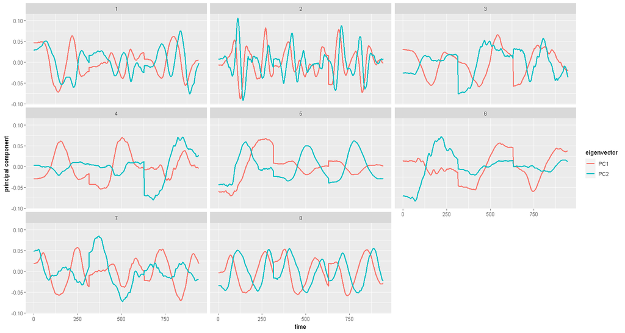

```r
ggplot(rotations_melt, aes(x=time, y=value, color=eigenvector)) +  geom_line(size=1) + facet_wrap(~class) + ylab("principal component")
```

###### In this setting, eigenvectors is used as represenation of time series, which can classify different patterns in different gestures. For example, Gesture3 and Gesture4 is the same movement but in the opposite directions. Eigenvectors of these two also implies this. hyphothesis. It looks like PC1 and PC2 follow similar pattern but it is the just opposite in some points of graph. In the same manner, likewise Gesture7 and Gesture8, the graphs of Gesture5 and Gesture6 also validate this behaviour